# 13 숫자

## 13.1 소개

수치형 벡터는 데이터 과학의 중추이며, 책의 앞부분에서 이미 여러 번 사용했습니다. 이제 R에서 수치형 벡터로 수행할 수 있는 작업을 체계적으로 조사하여 수치형 벡터와 관련된 향후 문제를 해결할 수 있는 준비를 확실히 할 때입니다.

문자열이 있는 경우 숫자를 만드는 몇 가지 도구를 제공하고 `count()`에 대해 조금 더 자세히 설명하는 것으로 시작하겠습니다. 그런 다음 `mutate()`와 잘 어울리는 다양한 수치 변환을 살펴볼 것입니다. 여기에는 다른 유형의 벡터에도 적용할 수 있지만 수치형 벡터에 자주 사용되는 보다 일반적인 변환이 포함됩니다. 마지막으로 `summarize()`와 잘 어울리는 요약 함수를 다루고 `mutate()`와 함께 사용하는 방법도 보여줄 것입니다.

### 13.1.1 선수 지식

이 장에서는 대부분 기본(base) R의 함수를 사용하는데, 이는 패키지를 로드하지 않고도 사용할 수 있습니다. 하지만 `mutate()` 및 `filter()`와 같은 tidyverse 함수 내에서 이러한 기본 R 함수를 사용할 것이므로 여전히 tidyverse가 필요합니다. 지난 장과 마찬가지로 nycflights13의 실제 예제와 `c()` 및 `tribble()`로 만든 장난감 예제를 사용할 것입니다.

```r
library(tidyverse)
library(nycflights13)
```

## 13.2 숫자 만들기

대부분의 경우 R의 수치 유형인 정수(integer) 또는 배정밀도 실수(double) 중 하나로 이미 기록된 숫자를 얻게 됩니다. 그러나 어떤 경우에는 열 헤더에서 피벗하여 생성했거나 데이터 가져오기 프로세스에서 문제가 발생했기 때문에 문자열로 된 숫자를 만날 수도 있습니다.

readr은 문자열을 숫자로 파싱하기 위한 두 가지 유용한 함수인 `parse_double()`과 `parse_number()`를 제공합니다. 숫자가 문자열로 작성되었을 때 `parse_double()`을 사용하세요:

```r
x <- c("1.2", "5.6", "1e3")
parse_double(x)
```

```
#> [1]    1.2    5.6 1000.0
```

문자열에 무시하고 싶은 숫자가 아닌 텍스트가 포함되어 있는 경우 `parse_number()`를 사용하세요. 이것은 통화 데이터와 백분율에 특히 유용합니다:

```r
x <- c("$1,234", "USD 3,513", "59%")
parse_number(x)
```

```
#> [1] 1234 3513   59
```

## 13.3 개수(Counts)

개수와 약간의 기본 산술만으로 얼마나 많은 데이터 과학을 수행할 수 있는지 놀랍기 때문에 dplyr은 `count()`를 사용하여 가능한 한 쉽게 개수를 셀 수 있도록 노력합니다. 이 함수는 분석 중 빠른 탐색 및 확인에 좋습니다:

```r
flights |> count(dest)
```

```
#> # A tibble: 105 × 2
#>   dest      n
#>   <chr> <int>
#> 1 ABQ     254
#> 2 ACK     265
#> 3 ALB     439
#> 4 ANC       8
#> 5 ATL   17215
#> 6 AUS    2439
#> # ℹ 99 more rows
```

(Chapter 4 의 조언에도 불구하고 계산이 예상대로 작동하는지 빠르게 확인하기 위해 콘솔에서 주로 사용되므로 `count()`는 보통 한 줄에 씁니다.)

가장 흔한 값을 보려면 `sort = TRUE`를 추가하세요:

```r
flights |> count(dest, sort = TRUE)
```

```
#> # A tibble: 105 × 2
#>   dest      n
#>   <chr> <int>
#> 1 ORD   17283
#> 2 ATL   17215
#> 3 LAX   16174
#> 4 BOS   15508
#> 5 MCO   14082
#> 6 CLT   14064
#> # ℹ 99 more rows
```

그리고 모든 값을 보려면 `|> View()` 또는 `|> print(n = Inf)`를 사용할 수 있다는 것을 기억하세요.

`group_by()`, `summarize()`, `n()`을 사용하여 “수동으로” 동일한 계산을 수행할 수 있습니다. 이것은 동시에 다른 요약을 계산할 수 있기 때문에 유용합니다:

```r
flights |>
  group_by(dest) |>
  summarize(
    n = n(),
    delay = mean(arr_delay, na.rm = TRUE)
  )
```

```
#> # A tibble: 105 × 3
#>   dest      n delay
#>   <chr> <int> <dbl>
#> 1 ABQ     254  4.38
#> 2 ACK     265  4.85
#> 3 ALB     439 14.4
#> 4 ANC       8 -2.5
#> 5 ATL   17215 11.3
#> 6 AUS    2439  6.02
#> # ℹ 99 more rows
```

`n()`은 인수를 받지 않고 대신 “현재” 그룹에 대한 정보에 액세스하는 특수 요약 함수입니다. 즉, dplyr 동사 내부에서만 작동합니다:

```r
n()
```

```
#> Error in `n()`:
#> ! Must only be used inside data-masking verbs like `mutate()`,
#>   `filter()`, and `group_by()`.
```

유용하게 사용할 수 있는 `n()`과 `count()`의 몇 가지 변형이 있습니다:

- `n_distinct(x)`는 하나 이상의 변수의 고유한(unique) 값의 수를 셉니다. 예를 들어 어떤 목적지가 가장 많은 항공사에 의해 운항되는지 파악할 수 있습니다:

  ```r
  flights |>
    group_by(dest) |>
    summarize(carriers = n_distinct(carrier)) |>
    arrange(desc(carriers))
  ```

  ```
  #> # A tibble: 105 × 2
  #>   dest  carriers
  #>   <chr>    <int>
  #> 1 ATL          7
  #> 2 BOS          7
  #> 3 CLT          7
  #> 4 ORD          7
  #> 5 TPA          7
  #> 6 AUS          6
  #> # ℹ 99 more rows
  ```

- 가중 개수는 합계입니다. 예를 들어 각 비행기가 비행한 마일 수를 “셀” 수 있습니다:

  ```r
  flights |>
    group_by(tailnum) |>
    summarize(miles = sum(distance))
  ```

  ```
  #> # A tibble: 4,044 × 2
  #>   tailnum  miles
  #>   <chr>    <dbl>
  #> 1 D942DN    3418
  #> 2 N0EGMQ  250866
  #> 3 N10156  115966
  #> 4 N102UW   25722
  #> 5 N103US   24619
  #> 6 N104UW   25157
  #> # ℹ 4,038 more rows
  ```

  가중 개수는 흔한 문제이므로 `count()`에는 동일한 작업을 수행하는 `wt` 인수가 있습니다:

  ```r
  flights |> count(tailnum, wt = distance)
  ```

- `sum()`과 `is.na()`를 결합하여 결측값을 셀 수 있습니다. `flights` 데이터셋에서 이것은 취소된 항공편을 나타냅니다:

  ```r
  flights |>
    group_by(dest) |>
    summarize(n_cancelled = sum(is.na(dep_time)))
  ```

  ```
  #> # A tibble: 105 × 2
  #>   dest  n_cancelled
  #>   <chr>       <int>
  #> 1 ABQ             0
  #> 2 ACK             0
  #> 3 ALB            20
  #> 4 ANC             0
  #> 5 ATL           317
  #> 6 AUS            21
  #> # ℹ 99 more rows
  ```

### 13.3.1 연습문제

1. `count()`를 사용하여 주어진 변수에 대해 결측값이 있는 행의 수를 어떻게 셀 수 있습니까?
2. `count()`에 대한 다음 호출을 확장하여 대신 `group_by()`, `summarize()`, `arrange()`를 사용하세요:
   1. `flights |> count(dest, sort = TRUE)`
   2. `flights |> count(tailnum, wt = distance)`

## 13.4 수치 변환

변환 함수는 출력이 입력과 길이가 같기 때문에 `mutate()`와 잘 작동합니다. 대부분의 변환 함수는 이미 기본 R에 내장되어 있습니다. 모두 나열하는 것은 비현실적이므로 이 섹션에서는 가장 유용한 것들을 보여줄 것입니다. 예를 들어 R은 꿈꿔왔던 모든 삼각 함수를 제공하지만 데이터 과학에는 거의 필요하지 않으므로 여기에는 나열하지 않습니다.

### 13.4.1 산술 및 재활용 규칙

Chapter 2 에서 산술(`+`, `-`, `*`, `/`, `^`)의 기초를 소개했고 그 이후로 많이 사용했습니다. 이 함수들은 초등학교에서 배운 것을 수행하기 때문에 엄청난 설명이 필요하지 않습니다. 하지만 왼쪽과 오른쪽의 길이가 다를 때 어떤 일이 일어나는지 결정하는 **재활용 규칙(recycling rules)** 에 대해 잠시 이야기해야 합니다. 이것은 `flights |> mutate(air_time = air_time / 60)`과 같은 작업에 중요합니다. `/` 왼쪽에는 336,776개의 숫자가 있지만 오른쪽에는 하나만 있기 때문입니다.

R은 짧은 벡터를 **재활용(recycling)**, 즉 반복하여 길이가 일치하지 않는 것을 처리합니다. 데이터 프레임 외부에서 몇 가지 벡터를 생성하면 이 작동 방식을 더 쉽게 볼 수 있습니다:

```r
x <- c(1, 2, 10, 20)
x / 5
```

```
#> [1] 0.2 0.4 2.0 4.0
```

```r
# 다음의 단축 표현입니다
x / c(5, 5, 5, 5)
```

```
#> [1] 0.2 0.4 2.0 4.0
```

일반적으로 단일 숫자(즉, 길이 1의 벡터)만 재활용하고 싶지만 R은 더 짧은 길이의 벡터를 재활용합니다. 보통(항상은 아니지만) 긴 벡터가 짧은 벡터의 배수가 아닌 경우 경고를 제공합니다:

```r
x * c(1, 2)
```

```
#> [1]  1  4 10 40
```

```r
x * c(1, 2, 3)
```

```
#> Warning in x * c(1, 2, 3): longer object length is not a multiple of shorter
#> object length
#> [1]  1  4 30 20
```

이러한 재활용 규칙은 논리 비교(`==`, `<`, `<=`, `>`, `>=`, `!=`)에도 적용되며, 실수로 `%in%` 대신 `==`를 사용하고 데이터 프레임의 행 수가 불행한 경우 놀라운 결과로 이어질 수 있습니다. 예를 들어 1월과 2월의 모든 항공편을 찾으려는 이 코드를 살펴보세요:

```r
flights |>
  filter(month == c(1, 2))
```

```
#> # A tibble: 25,977 × 19
#>    year month   day dep_time sched_dep_time dep_delay arr_time sched_arr_time
#>   <int> <int> <int>    <int>          <int>     <dbl>    <int>          <int>
#> 1  2013     1     1      517            515         2      830            819
#> 2  2013     1     1      542            540         2      923            850
#> 3  2013     1     1      554            600        -6      812            837
#> 4  2013     1     1      555            600        -5      913            854
#> 5  2013     1     1      557            600        -3      838            846
#> 6  2013     1     1      558            600        -2      849            851
#> # ℹ 25,971 more rows
#> # ℹ 11 more variables: arr_delay <dbl>, carrier <chr>, flight <int>, …
```

코드는 오류 없이 실행되지만 원하는 것을 반환하지 않습니다. 재활용 규칙 때문에 홀수 행에서 1월에 출발한 항공편과 짝수 행에서 2월에 출발한 항공편을 찾습니다. 그리고 불행히도 `flights`의 행 수가 짝수이므로 경고가 없습니다.

이러한 유형의 침묵의 실패로부터 보호하기 위해 대부분의 tidyverse 함수는 단일 값만 재활용하는 더 엄격한 형태의 재활용을 사용합니다. 불행히도 핵심 계산이 `filter()`가 아니라 기본 R 함수 `==`에 의해 수행되므로 여기에서는 도움이 되지 않습니다.

### 13.4.2 최소 및 최대

산술 함수는 한 쌍의 변수와 함께 작동합니다. 밀접하게 관련된 두 함수는 `pmin()`과 `pmax()`이며, 두 개 이상의 변수가 주어지면 각 행에서 가장 작은 값이나 가장 큰 값을 반환합니다:

```r
df <- tribble(
  ~x, ~y,
  1,  3,
  5,  2,
  7, NA,
)

df |>
  mutate(
    min = pmin(x, y, na.rm = TRUE),
    max = pmax(x, y, na.rm = TRUE)
  )
```

```
#> # A tibble: 3 × 4
#>       x     y   min   max
#>   <dbl> <dbl> <dbl> <dbl>
#> 1     1     3     1     3
#> 2     5     2     2     5
#> 3     7    NA     7     7
```

이것들은 여러 관측값을 받아 단일 값을 반환하는 요약 함수 `min()` 및 `max()`와는 다릅니다. 모든 최소값과 모든 최대값이 동일한 값을 가질 때 잘못된 형식을 사용했음을 알 수 있습니다:

```r
df |>
  mutate(
    min = min(x, y, na.rm = TRUE),
    max = max(x, y, na.rm = TRUE)
  )
```

```
#> # A tibble: 3 × 4
#>       x     y   min   max
#>   <dbl> <dbl> <dbl> <dbl>
#> 1     1     3     1     7
#> 2     5     2     1     7
#> 3     7    NA     1     7
```

### 13.4.3 모듈러 연산

모듈러 연산은 소수점에 대해 배우기 전에 수행했던 수학 유형, 즉 정수와 나머지를 산출하는 나눗셈의 기술 이름입니다. R에서 `%/%`는 정수 나눗셈을 수행하고 `%%`는 나머지를 계산합니다:

```r
1:10 %/% 3
```

```
#>  [1] 0 0 1 1 1 2 2 2 3 3
```

```r
1:10 %% 3
```

```
#>  [1] 1 2 0 1 2 0 1 2 0 1
```

모듈러 연산은 `flights` 데이터셋에 편리합니다. `sched_dep_time` 변수를 `hour`와 `minute`로 푸는 데 사용할 수 있기 때문입니다:

```r
flights |>
  mutate(
    hour = sched_dep_time %/% 100,
    minute = sched_dep_time %% 100,
    .keep = "used"
  )
```

```
#> # A tibble: 336,776 × 3
#>   sched_dep_time  hour minute
#>            <int> <dbl>  <dbl>
#> 1            515     5     15
#> 2            529     5     29
#> 3            540     5     40
#> 4            545     5     45
#> 5            600     6      0
#> 6            558     5     58
#> # ℹ 336,770 more rows
```

이것을 Section 12.4 의 `mean(is.na(x))` 트릭과 결합하여 취소된 항공편의 비율이 하루 동안 어떻게 변하는지 확인할 수 있습니다. 결과는 Figure 13.1 에 나와 있습니다.

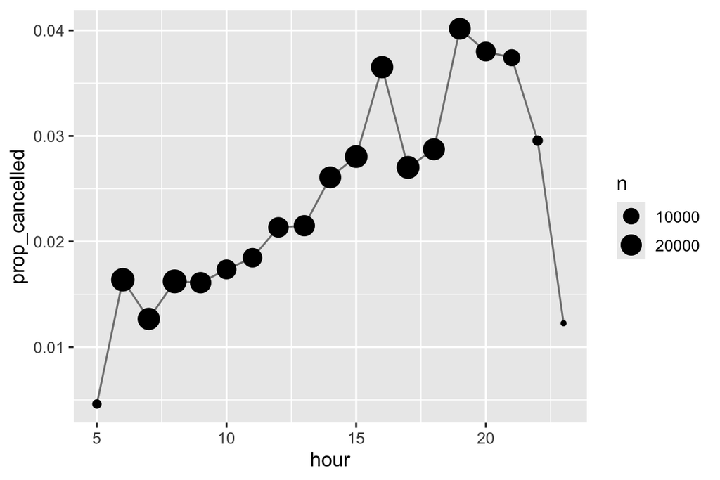

Figure 13.1: x축에 예정된 출발 시간, y축에 취소된 항공편의 비율이 있는 선 플롯. 취소는 오후 8시까지 하루 종일 누적되는 것 같으며, 매우 늦은 항공편은 취소될 가능성이 훨씬 적습니다.

```r
flights |>
  group_by(hour = sched_dep_time %/% 100) |>
  summarize(prop_cancelled = mean(is.na(dep_time)), n = n()) |>
  filter(hour > 1) |>
  ggplot(aes(x = hour, y = prop_cancelled)) +
  geom_line(color = "grey50") +
  geom_point(aes(size = n))
```

### 13.4.4 로그

로그는 여러 자릿수(orders of magnitude)에 걸친 데이터를 처리하고 지수 성장을 선형 성장으로 변환하는 데 매우 유용한 변환입니다. R에서는 세 가지 로그를 선택할 수 있습니다: `log()`(자연 로그, 밑 e), `log2()`(밑 2), `log10()`(밑 10). `log2()` 또는 `log10()`을 사용하는 것이 좋습니다. `log2()`는 로그 척도에서 1의 차이가 원래 척도에서 두 배에 해당하고 -1의 차이가 절반에 해당하기 때문에 해석하기 쉽습니다. 반면 `log10()`은 역변환하기 쉽습니다(예: 3은 10^3 = 1000). `log()`의 역함수는 `exp()`입니다. `log2()` 또는 `log10()`의 역함수를 계산하려면 `2^` 또는 `10^`를 사용해야 합니다.

### 13.4.5 반올림

숫자를 가장 가까운 정수로 반올림하려면 `round(x)`를 사용하세요:

```r
round(123.456)
```

```
#> [1] 123
```

두 번째 인수 `digits`로 반올림의 정밀도를 제어할 수 있습니다. `round(x, digits)`는 가장 가까운 `10^-n`으로 반올림하므로 `digits = 2`는 가장 가까운 0.01로 반올림합니다. 이 정의는 `round(x, -3)`이 가장 가까운 천 단위로 반올림한다는 것을 의미하므로 유용합니다:

```r
round(123.456, 2)  # 두 자리
```

```
#> [1] 123.46
```

```r
round(123.456, 1)  # 한 자리
```

```
#> [1] 123.5
```

```r
round(123.456, -1) # 가장 가까운 십 단위로 반올림
```

```
#> [1] 120
```

```r
round(123.456, -2) # 가장 가까운 백 단위로 반올림
```

```
#> [1] 100
```

`round()`에는 언뜻 보기에 놀라운 이상한 점이 하나 있습니다:

```r
round(c(1.5, 2.5))
```

```
#> [1] 2 2
```

`round()`는 “반을 짝수로 반올림(round half to even)” 또는 은행가 반올림(Banker’s rounding)이라고 알려진 방법을 사용합니다: 숫자가 두 정수 사이의 중간에 있으면 **짝수** 정수로 반올림됩니다. 이것은 반올림을 편향되지 않게 유지하기 때문에 좋은 전략입니다. 0.5의 절반은 올림되고 절반은 내림됩니다.

`round()`는 항상 내림하는 `floor()`와 항상 올림하는 `ceiling()`과 짝을 이룹니다:

```r
x <- 123.456

floor(x)
```

```
#> [1] 123
```

```r
ceiling(x)
```

```
#> [1] 124
```

이 함수들에는 `digits` 인수가 없으므로 대신 축소하고 반올림한 다음 다시 확대할 수 있습니다:

```r
# 가장 가까운 두 자리로 내림
floor(x / 0.01) * 0.01
```

```
#> [1] 123.45
```

```r
# 가장 가까운 두 자리로 올림
ceiling(x / 0.01) * 0.01
```

```
#> [1] 123.46
```

`round()`를 다른 숫자의 배수로 반올림하려는 경우 동일한 기술을 사용할 수 있습니다:

```r
# 가장 가까운 4의 배수로 반올림
round(x / 4) * 4
```

```
#> [1] 124
```

```r
# 가장 가까운 0.25로 반올림
round(x / 0.25) * 0.25
```

```
#> [1] 123.5
```

### 13.4.6 숫자를 범위로 자르기

수치형 벡터를 이산 버킷으로 나누려면(일명 비닝) `cut()`[^1]을 사용하세요:

```r
x <- c(1, 2, 5, 10, 15, 20)
cut(x, breaks = c(0, 5, 10, 15, 20))
```

```
#> [1] (0,5]   (0,5]   (0,5]   (5,10]  (10,15] (15,20]
#> Levels: (0,5] (5,10] (10,15] (15,20]
```

나누기(breaks)는 균등하게 간격을 둘 필요가 없습니다:

```r
cut(x, breaks = c(0, 5, 10, 100))
```

```
#> [1] (0,5]    (0,5]    (0,5]    (5,10]   (10,100] (10,100]
#> Levels: (0,5] (5,10] (10,100]
```

선택적으로 자신만의 `labels`를 제공할 수 있습니다. `labels`는 `breaks`보다 하나 적어야 한다는 점에 유의하세요.

```r
cut(x,
  breaks = c(0, 5, 10, 15, 20),
  labels = c("sm", "md", "lg", "xl")
)
```

```
#> [1] sm sm sm md lg xl
#> Levels: sm md lg xl
```

나누기 범위 밖의 값은 `NA`가 됩니다:

```r
y <- c(NA, -10, 5, 10, 30)
cut(y, breaks = c(0, 5, 10, 15, 20))
```

```
#> [1] <NA>   <NA>   (0,5]  (5,10] <NA>
#> Levels: (0,5] (5,10] (10,15] (15,20]
```

구간이 `[a, b)`인지 `(a, b]`인지, 가장 낮은 구간이 `[a, b]`여야 하는지 제어하는 `right` 및 `include.lowest`와 같은 다른 유용한 인수에 대해서는 설명서를 참조하세요.

### 13.4.7 누적 및 롤링 집계

기본 R은 누적 합, 곱, 최소 및 최대를 위해 `cumsum()`, `cumprod()`, `cummin()`, `cummax()`를 제공합니다. dplyr은 누적 평균을 위한 `cummean()`을 제공합니다. 누적 합이 실제로 가장 많이 나오는 경향이 있습니다:

```r
x <- 1:10
cumsum(x)
```

```
#>  [1]  1  3  6 10 15 21 28 36 45 55
```

더 복잡한 롤링 또는 슬라이딩 집계가 필요한 경우 [slider](https://slider.r-lib.org/) 패키지를 사용해 보세요.

### 13.4.8 연습문제

1. Figure 13.1 를 생성하는 데 사용된 코드의 각 줄이 무엇을 하는지 말로 설명하세요.
2. R은 어떤 삼각 함수를 제공합니까? 이름을 추측하고 설명서를 찾아보세요. 도(degrees)를 사용합니까, 아니면 라디안(radians)을 사용합니까?
3. 현재 `dep_time`과 `sched_dep_time`은 보기에 편리하지만 실제로는 연속적인 숫자가 아니기 때문에 계산하기 어렵습니다. 아래 코드를 실행하여 기본적인 문제를 볼 수 있습니다. 각 시간 사이에 간격이 있습니다.

   ```r
   flights |>
     filter(month == 1, day == 1) |>
     ggplot(aes(x = sched_dep_time, y = dep_delay)) +
     geom_point()
   ```

   더 진실한 시간 표현(소수 시간 또는 자정 이후 분)으로 변환하세요.
4. `dep_time`과 `arr_time`을 가장 가까운 5분 단위로 반올림하세요.

## 13.5 일반적인 변환

다음 섹션에서는 수치형 벡터에 자주 사용되지만 다른 모든 열 유형에도 적용할 수 있는 몇 가지 일반적인 변환을 설명합니다.

### 13.5.1 순위(Ranks)

dplyr은 SQL에서 영감을 얻은 여러 순위 함수를 제공하지만 항상 `dplyr::min_rank()`로 시작해야 합니다. 동점을 처리하는 일반적인 방법(예: 1등, 2등, 2등, 4등)을 사용합니다.

```r
x <- c(1, 5, 5, 17, 22, NA)
min_rank(x)
```

```
#> [1]  1  2  2  4  5 NA
```

가장 작은 값이 가장 낮은 순위를 얻습니다. 가장 큰 값에 가장 작은 순위를 부여하려면 `desc(x)`를 사용하세요:

```r
min_rank(desc(x))
```

```
#> [1]  5  3  3  2  1 NA
```

`min_rank()`가 필요한 작업을 수행하지 않으면 변형인 `dplyr::row_number()`, `dplyr::dense_rank()`, `dplyr::percent_rank()`, `dplyr::cume_dist()`를 살펴보세요. 자세한 내용은 설명서를 참조하세요.

```r
df <- tibble(x = x)
df |>
  mutate(
    row_number = row_number(x),
    dense_rank = dense_rank(x),
    percent_rank = percent_rank(x),
    cume_dist = cume_dist(x)
  )
```

```
#> # A tibble: 6 × 5
#>       x row_number dense_rank percent_rank cume_dist
#>   <dbl>      <int>      <int>        <dbl>     <dbl>
#> 1     1          1          1         0          0.2
#> 2     5          2          2         0.25       0.6
#> 3     5          3          2         0.25       0.6
#> 4    17          4          3         0.75       0.8
#> 5    22          5          4         1          1
#> 6    NA         NA         NA        NA         NA
```

기본 R의 `rank()`에 적절한 `ties.method` 인수를 선택하여 동일한 결과를 많이 얻을 수 있습니다. 아마도 `NA`를 `NA`로 유지하려면 `na.last = "keep"`을 설정하고 싶을 것입니다.

`row_number()`는 dplyr 동사 내부에서 인수 없이 사용할 수도 있습니다. 이 경우 “현재” 행의 번호를 제공합니다. `%%` 또는 `%/%`와 결합하면 데이터를 비슷한 크기의 그룹으로 나누는 유용한 도구가 될 수 있습니다:

```r
df <- tibble(id = 1:10)

df |>
  mutate(
    row0 = row_number() - 1,
    three_groups = row0 %% 3,
    three_in_each_group = row0 %/% 3
  )
```

```
#> # A tibble: 10 × 4
#>      id  row0 three_groups three_in_each_group
#>   <int> <dbl>        <dbl>               <dbl>
#> 1     1     0            0                   0
#> 2     2     1            1                   0
#> 3     3     2            2                   0
#> 4     4     3            0                   1
#> 5     5     4            1                   1
#> 6     6     5            2                   1
#> # ℹ 4 more rows
```

### 13.5.2 오프셋(Offsets)

`dplyr::lead()`와 `dplyr::lag()`를 사용하면 “현재” 값 바로 앞이나 뒤의 값을 참조할 수 있습니다. 입력과 길이가 같은 벡터를 반환하며 시작이나 끝에 `NA`가 채워집니다:

```r
x <- c(2, 5, 11, 11, 19, 35)
lag(x)
```

```
#> [1] NA  2  5 11 11 19
```

```r
lead(x)
```

```
#> [1]  5 11 11 19 35 NA
```

- `x - lag(x)`는 현재 값과 이전 값의 차이를 제공합니다.

  ```r
  x - lag(x)
  ```

  ```
  #> [1] NA  3  6  0  8 16
  ```

- `x == lag(x)`는 현재 값이 언제 변경되는지 알려줍니다.

  ```r
  x == lag(x)
  ```

  ```
  #> [1]    NA FALSE FALSE  TRUE FALSE FALSE
  ```

두 번째 인수 `n`을 사용하여 한 위치 이상 리드하거나 래그할 수 있습니다.

### 13.5.3 연속 식별자

때로는 이벤트가 발생할 때마다 새 그룹을 시작하고 싶을 때가 있습니다. 예를 들어 웹사이트 데이터를 볼 때 이벤트를 세션으로 나누고 싶은데, 마지막 활동 이후 `x`분 이상의 간격이 있은 후 새 세션을 시작하는 것이 일반적입니다. 예를 들어 누군가가 웹사이트를 방문한 시간이 있다고 상상해 보세요:

```r
events <- tibble(
  time = c(0, 1, 2, 3, 5, 10, 12, 15, 17, 19, 20, 27, 28, 30)
)
```

그리고 각 이벤트 사이의 시간을 계산하고 자격을 갖출 만큼 충분히 큰 간격이 있는지 파악했습니다:

```r
events <- events |>
  mutate(
    diff = time - lag(time, default = first(time)),
    has_gap = diff >= 5
  )
events
```

```
#> # A tibble: 14 × 3
#>    time  diff has_gap
#>   <dbl> <dbl> <lgl>
#> 1     0     0 FALSE
#> 2     1     1 FALSE
#> 3     2     1 FALSE
#> 4     3     1 FALSE
#> 5     5     2 FALSE
#> 6    10     5 TRUE
#> # ℹ 8 more rows
```

하지만 그 논리형 벡터에서 어떻게 `group_by()`할 수 있는 것으로 갈 수 있을까요? Section 13.4.7 의 `cumsum()`이 구해주러 옵니다. 갭, 즉 `has_gap`이 `TRUE`이면 `group`이 1씩 증가하기 때문입니다(Section 12.4.2):

```r
events |> mutate(
  group = cumsum(has_gap)
)
```

```
#> # A tibble: 14 × 4
#>    time  diff has_gap group
#>   <dbl> <dbl> <lgl>   <int>
#> 1     0     0 FALSE       0
#> 2     1     1 FALSE       0
#> 3     2     1 FALSE       0
#> 4     3     1 FALSE       0
#> 5     5     2 FALSE       0
#> 6    10     5 TRUE        1
#> # ℹ 8 more rows
```

그룹화 변수를 만드는 또 다른 접근 방식은 `consecutive_id()`로, 인수 중 하나가 변경될 때마다 새 그룹을 시작합니다. 예를 들어 [이 stackoverflow 질문](https://stackoverflow.com/questions/27482712)에서 영감을 받아 반복되는 값이 많은 데이터 프레임이 있다고 상상해 보세요:

```r
df <- tibble(
  x = c("a", "a", "a", "b", "c", "c", "d", "e", "a", "a", "b", "b"),
  y = c(1, 2, 3, 2, 4, 1, 3, 9, 4, 8, 10, 199)
)
```

반복되는 각 `x`의 첫 번째 행을 유지하려면 `group_by()`, `consecutive_id()`, `slice_head()`를 사용할 수 있습니다:

```r
df |>
  group_by(id = consecutive_id(x)) |>
  slice_head(n = 1)
```

```
#> # A tibble: 7 × 3
#> # Groups:   id [7]
#>   x         y    id
#>   <chr> <dbl> <int>
#> 1 a         1     1
#> 2 b         2     2
#> 3 c         4     3
#> 4 d         3     4
#> 5 e         9     5
#> 6 a         4     6
#> # ℹ 1 more row
```

### 13.5.4 연습문제

1. 순위 함수를 사용하여 가장 많이 지연된 10개의 항공편을 찾으세요. 동점은 어떻게 처리하고 싶습니까? `min_rank()`에 대한 설명을 주의 깊게 읽으세요.
2. 어떤 비행기(`tailnum`)가 정시 기록이 가장 나쁩니까?
3. 지연을 최대한 피하고 싶다면 하루 중 언제 비행해야 합니까?
4. `flights |> group_by(dest) |> filter(row_number() < 4)`는 무엇을 합니까? `flights |> group_by(dest) |> filter(row_number(dep_delay) < 4)`는 무엇을 합니까?
5. 각 목적지에 대해 총 지연 분을 계산하세요. 각 항공편에 대해 목적지에 대한 총 지연의 비율을 계산하세요.
6. 지연은 일반적으로 시간적으로 상관관계가 있습니다: 초기 지연을 유발한 문제가 해결된 후에도 이전 항공편이 떠날 수 있도록 나중 항공편이 지연됩니다. `lag()`를 사용하여 한 시간 동안의 평균 항공편 지연이 이전 시간의 평균 지연과 어떻게 관련되어 있는지 탐색하세요.

   ```r
   flights |>
     mutate(hour = dep_time %/% 100) |>
     group_by(year, month, day, hour) |>
     summarize(
       dep_delay = mean(dep_delay, na.rm = TRUE),
       n = n(),
       .groups = "drop"
     ) |>
     filter(n > 5)
   ```

7. 각 목적지를 살펴보세요. 의심스럽게 빠른 항공편(즉, 잠재적인 데이터 입력 오류를 나타내는 항공편)을 찾을 수 있습니까? 해당 목적지로 가는 가장 짧은 항공편에 대한 항공편의 비행 시간을 계산하세요. 공중에서 가장 많이 지연된 항공편은 무엇입니까?
8. 적어도 두 항공사가 운항하는 모든 목적지를 찾으세요. 그 목적지들을 사용하여 동일한 목적지에 대한 성과를 기반으로 항공사의 상대적 순위를 매기세요.

## 13.6 숫자 요약

이미 소개한 개수, 평균, 합계만 사용해도 많은 것을 얻을 수 있지만 R은 다른 많은 유용한 요약 함수를 제공합니다. 유용할 만한 선택 항목은 다음과 같습니다.

### 13.6.1 중심

지금까지 우리는 주로 값 벡터의 중심을 요약하기 위해 `mean()`을 사용했습니다. Section 3.6 에서 보았듯이 평균은 합계를 개수로 나눈 것이기 때문에 소수의 비정상적으로 높거나 낮은 값에도 민감합니다. 대안은 `median()`을 사용하는 것입니다. 이는 벡터의 “중간”에 있는 값, 즉 값의 50%는 그 위에 있고 50%는 그 아래에 있는 값을 찾습니다. 관심 있는 변수의 분포 모양에 따라 평균 또는 중앙값이 중심의 더 나은 척도가 될 수 있습니다. 예를 들어 대칭 분포의 경우 일반적으로 평균을 보고하는 반면 치우친 분포의 경우 일반적으로 중앙값을 보고합니다.

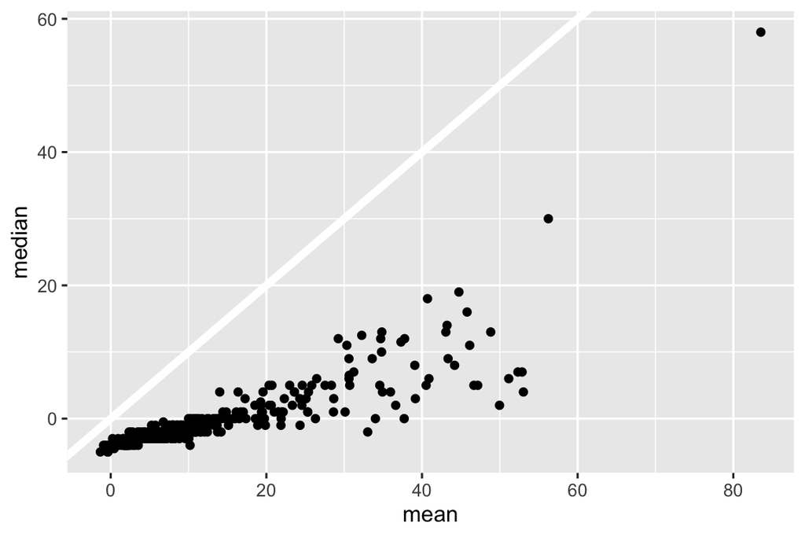

Figure 13.2: 일일 출발 지연을 평균 대신 중앙값으로 요약할 때의 차이를 보여주는 산점도.

```r
flights |>
  group_by(year, month, day) |>
  summarize(
    mean = mean(dep_delay, na.rm = TRUE),
    median = median(dep_delay, na.rm = TRUE),
    n = n(),
    .groups = "drop"
  ) |>
  ggplot(aes(x = mean, y = median)) +
  geom_abline(slope = 1, intercept = 0, color = "white", linewidth = 2) +
  geom_point()
```

**최빈값(mode)**, 즉 가장 흔한 값에 대해서도 궁금할 수 있습니다. 이것은 매우 간단한 경우에만 잘 작동하는 요약(그래서 고등학교에서 배웠을 수도 있음)이지만 많은 실제 데이터셋에서는 잘 작동하지 않습니다. 데이터가 이산형인 경우 가장 흔한 값이 여러 개 있을 수 있고, 데이터가 연속형인 경우 모든 값이 아주 조금씩 다르기 때문에 가장 흔한 값이 없을 수 있습니다. 이러한 이유로 통계학자들은 최빈값을 잘 사용하지 않는 경향이 있으며 기본 R에는 포함된 최빈값 함수가 없습니다[^2].

### 13.6.2 최소, 최대 및 분위수

중심 이외의 위치에 관심이 있다면 어떻게 해야 할까요? `min()`과 `max()`는 가장 큰 값과 가장 작은 값을 제공합니다. 또 다른 강력한 도구는 중앙값의 일반화인 `quantile()`입니다. `quantile(x, 0.25)`는 값의 25%보다 큰 `x` 값을 찾고, `quantile(x, 0.5)`는 중앙값과 동일하며, `quantile(x, 0.95)`는 값의 95%보다 큰 값을 찾습니다.

`flights` 데이터의 경우 가장 많이 지연된 항공편의 5%는 매우 극단적일 수 있으므로 최대값보다는 지연의 95% 분위수를 보고 싶을 수 있습니다.

```r
flights |>
  group_by(year, month, day) |>
  summarize(
    max = max(dep_delay, na.rm = TRUE),
    q95 = quantile(dep_delay, 0.95, na.rm = TRUE),
    .groups = "drop"
  )
```

```
#> # A tibble: 365 × 5
#>    year month   day   max   q95
#>   <int> <int> <int> <dbl> <dbl>
#> 1  2013     1     1   853  70.1
#> 2  2013     1     2   379  85
#> 3  2013     1     3   291  68
#> 4  2013     1     4   288  60
#> 5  2013     1     5   327  41
#> 6  2013     1     6   202  51
#> # ℹ 359 more rows
```

### 13.6.3 산포(Spread)

때로는 데이터의 대부분이 어디에 있는지보다는 어떻게 퍼져 있는지에 관심이 있을 수 있습니다. 일반적으로 사용되는 두 가지 요약은 표준 편차 `sd(x)`와 사분위수 범위 `IQR()`입니다. `sd()`는 아마 이미 익숙할 것이므로 여기서 설명하지 않겠지만 `IQR()`은 생소할 수 있습니다. 이것은 `quantile(x, 0.75) - quantile(x, 0.25)`이며 데이터의 중간 50%를 포함하는 범위를 제공합니다.

이것을 사용하여 `flights` 데이터의 작은 이상함을 드러낼 수 있습니다. 공항은 항상 같은 장소에 있기 때문에 출발지와 목적지 사이의 거리 산포가 0일 것이라고 예상할 수 있습니다. 그러나 아래 코드는 [EGE](https://en.wikipedia.org/wiki/Eagle_County_Regional_Airport) 공항에 대한 데이터 이상함을 보여줍니다:

```r
flights |>
  group_by(origin, dest) |>
  summarize(
    distance_iqr = IQR(distance),
    n = n(),
    .groups = "drop"
  ) |>
  filter(distance_iqr > 0)
```

```
#> # A tibble: 2 × 4
#>   origin dest  distance_iqr     n
#>   <chr>  <chr>        <dbl> <int>
#> 1 EWR    EGE              1   110
#> 2 JFK    EGE              1   103
```

### 13.6.4 분포

위에서 설명한 모든 요약 통계는 분포를 단일 숫자로 줄이는 방법이라는 점을 기억할 가치가 있습니다. 이는 근본적으로 축소적이며 잘못된 요약을 선택하면 그룹 간의 중요한 차이를 쉽게 놓칠 수 있음을 의미합니다. 그렇기 때문에 요약 통계를 확정하기 전에 항상 분포를 시각화하는 것이 좋습니다.

Figure 13.3 는 출발 지연의 전체 분포를 보여줍니다. 분포가 너무 치우쳐 있어서 데이터의 대부분을 보려면 확대해야 합니다. 이는 평균이 좋은 요약이 아닐 수 있으며 대신 중앙값을 선호할 수 있음을 시사합니다.

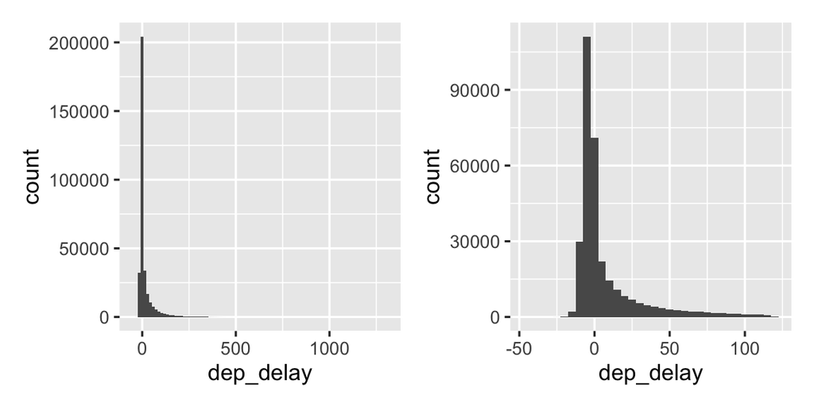

Figure 13.3: (왼쪽) 전체 데이터의 히스토그램은 매우 치우쳐 있어 세부 정보를 얻기 어렵습니다. (오른쪽) 2시간 미만의 지연으로 확대하면 대부분의 관측값에서 무슨 일이 일어나고 있는지 볼 수 있습니다.

하위 그룹의 분포가 전체와 유사한지 확인하는 것도 좋습니다. 다음 플롯에서는 `dep_delay`의 365개 빈도 다각형(매일 하나씩)이 겹쳐져 있습니다. 분포는 일반적인 패턴을 따르는 것으로 보이며 매일 동일한 요약을 사용해도 괜찮음을 시사합니다.

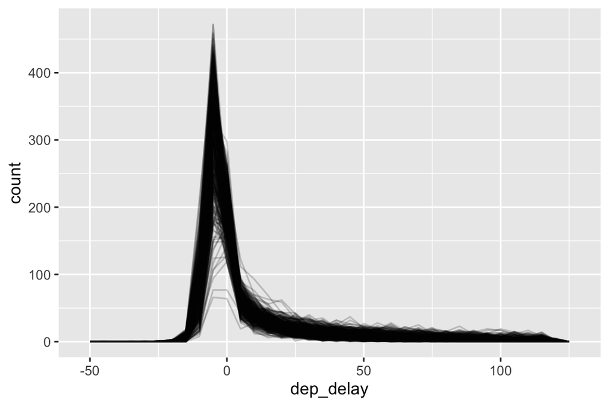

```r
flights |>
  filter(dep_delay < 120) |>
  ggplot(aes(x = dep_delay, group = interaction(day, month))) +
  geom_freqpoly(binwidth = 5, alpha = 1/5)
```

작업 중인 데이터에 특별히 맞춤화된 사용자 정의 요약을 탐색하는 것을 두려워하지 마세요. 이 경우 일찍 출발한 항공편과 늦게 출발한 항공편을 별도로 요약하거나 값이 너무 심하게 치우쳐 있으므로 로그 변환을 시도해 볼 수 있습니다. 마지막으로 Section 3.6 에서 배운 내용을 잊지 마세요: 수치 요약을 생성할 때마다 각 그룹의 관측값 수를 포함하는 것이 좋습니다.

### 13.6.5 위치

수치형 벡터에 유용하지만 다른 모든 유형의 값과도 작동하는 요약 유형이 하나 더 있습니다. 특정 위치의 값을 추출하는 것입니다: `first(x)`, `last(x)`, `nth(x, n)`.

예를 들어 매일 첫 번째, 다섯 번째, 마지막 출발을 찾을 수 있습니다:

```r
flights |>
  group_by(year, month, day) |>
  summarize(
    first_dep = first(dep_time, na_rm = TRUE),
    fifth_dep = nth(dep_time, 5, na_rm = TRUE),
    last_dep = last(dep_time, na_rm = TRUE)
  )
```

```
#> # A tibble: 365 × 6
#> # Groups:   year, month [12]
#>    year month   day first_dep fifth_dep last_dep
#>   <int> <int> <int>     <int>     <int>    <int>
#> 1  2013     1     1       517       554     2356
#> 2  2013     1     2        42       535     2354
#> 3  2013     1     3        32       520     2349
#> 4  2013     1     4        25       531     2358
#> 5  2013     1     5        14       534     2357
#> 6  2013     1     6        16       555     2355
#> # ℹ 359 more rows
```

(참고: dplyr 함수는 `_`를 사용하여 함수 및 인수 이름의 구성 요소를 구분하므로 이러한 함수는 `na.rm` 대신 `na_rm`을 사용합니다.)

Section 27.2 에서 다시 다룰 `[`에 익숙하다면 이러한 함수가 필요한지 궁금할 수 있습니다. 세 가지 이유가 있습니다: `default` 인수를 사용하면 지정된 위치가 존재하지 않는 경우 기본값을 제공할 수 있고, `order_by` 인수를 사용하면 행의 순서를 로컬에서 재정의할 수 있으며, `na_rm` 인수를 사용하면 결측값을 삭제할 수 있습니다.

위치에서 값을 추출하는 것은 순위에 대한 필터링을 보완합니다. 필터링은 각 관측값이 별도의 행에 있는 모든 변수를 제공합니다:

```r
flights |>
  group_by(year, month, day) |>
  mutate(r = min_rank(sched_dep_time)) |>
  filter(r %in% c(1, max(r)))
```

```
#> # A tibble: 1,195 × 20
#> # Groups:   year, month, day [365]
#>    year month   day dep_time sched_dep_time dep_delay arr_time sched_arr_time
#>   <int> <int> <int>    <int>          <int>     <dbl>    <int>          <int>
#> 1  2013     1     1      517            515         2      830            819
#> 2  2013     1     1     2353           2359        -6      425            445
#> 3  2013     1     1     2353           2359        -6      418            442
#> 4  2013     1     1     2356           2359        -3      425            437
#> 5  2013     1     2       42           2359        43      518            442
#> 6  2013     1     2      458            500        -2      703            650
#> # ℹ 1,189 more rows
#> # ℹ 12 more variables: arr_delay <dbl>, carrier <chr>, flight <int>, …
```

### 13.6.6 `mutate()`와 함께

이름에서 알 수 있듯이 요약 함수는 일반적으로 `summarize()`와 짝을 이룹니다. 그러나 Section 13.4.1 에서 논의한 재활용 규칙 때문에 `mutate()`와 유용하게 짝을 이룰 수도 있으며, 특히 어떤 종류의 그룹 표준화를 수행하려는 경우에 그렇습니다. 예를 들어:

- `x / sum(x)`는 전체에 대한 비율을 계산합니다.
- `(x - mean(x)) / sd(x)`는 Z-점수(평균 0 및 표준 편차 1로 표준화)를 계산합니다.
- `(x - min(x)) / (max(x) - min(x))`는 범위 [0, 1]로 표준화합니다.
- `x / first(x)`는 첫 번째 관측값을 기반으로 지수를 계산합니다.

### 13.6.7 연습문제

1. 항공편 그룹의 전형적인 지연 특성을 평가하는 적어도 5가지 다른 방법을 브레인스토밍하세요. `mean()`은 언제 유용합니까? `median()`은 언제 유용합니까? 다른 것을 사용하고 싶을 때는 언제입니까? 도착 지연을 사용해야 할까요, 출발 지연을 사용해야 할까요? `planes`의 데이터를 사용하고 싶은 이유는 무엇일까요?
2. 어떤 목적지가 공중 속도에서 가장 큰 변동을 보입니까?
3. EGE의 모험을 더 탐구하기 위해 플롯을 만드세요. 공항이 위치를 옮겼다는 증거를 찾을 수 있습니까? 차이를 설명할 수 있는 다른 변수를 찾을 수 있습니까?

## 13.7 요약

여러분은 이미 숫자를 다루는 많은 도구에 익숙하며 이 장을 읽고 나면 R에서 그것들을 사용하는 방법을 알게 되었습니다. 또한 순위 및 오프셋과 같이 일반적으로 수치형 벡터에 적용되지만 배타적이지는 않은 유용한 일반 변환 몇 가지를 배웠습니다. 마지막으로 여러 수치 요약을 살펴보고 고려해야 할 몇 가지 통계적 과제에 대해 논의했습니다.

다음 두 장에 걸쳐 stringr 패키지로 문자열을 다루는 방법에 대해 자세히 알아볼 것입니다. 문자열은 큰 주제이므로 문자열의 기초에 대한 장과 정규 표현식에 대한 장 두 개를 얻습니다.

[^1]: ggplot2는 `cut_interval()`, `cut_number()`, `cut_width()`에서 일반적인 경우에 대한 몇 가지 도우미를 제공합니다. ggplot2는 인정하건대 이러한 함수가 살기에는 이상한 곳이지만 히스토그램 계산의 일부로 유용하며 tidyverse의 다른 부분이 존재하기 전에 작성되었습니다.
[^2]: `mode()` 함수는 완전히 다른 일을 합니다!